# Wprowadzenie do środowiska R

22 luty 2019

## Dlaczego Pakiet R?

- R to język programowania, środowisko oraz platforma,
- powstał z inicjatywy Roberta Gentlemana i Ross Ihake (znani jako R&R),
- od roku 1997 rozwojem R kieruje liczny zespół osób nazwanych „core team”,
- język R jest podobny do języka S opracowanego w laboratoriach Bell’a,
- R jest projektem GNU opartym o licencje GPL GNU (darmowy do wszystkich zastosowań),
- wykorzystując go w pracy naukowej, warto zaznaczyć to w referencjach:

## Dlaczego Pakiet R?

```r
citation()
```

```
##
##
##   R Core Team (2018). R: A language and environment for
##   statistical computing. R Foundation for Statistical Computing,
##   Vienna, Austria. URL https://www.R-project.org/.
##
## A BibTeX entry for LaTeX users is
##
##   @Manual{,
##     title = {R: A Language and Environment for Statistical Computing},
##     author = {{R Core Team}},
##     organization = {R Foundation for Statistical Computing},
##     address = {Vienna, Austria},
##     year = {2018},
##     url = {https://www.R-project.org/},
##   }
##
## We have invested a lot of time and effort in creating R, please
## cite it when using it for data analysis. See also
## 'citation("pkgname")' for citing R packages.
```

## Dlaczego Pakiet R?

[figure not shown]

## Dlaczego Pakiet R?

- możliwość tworzenia i upowszechnianie **pakietów** (CRAN, GitHub),

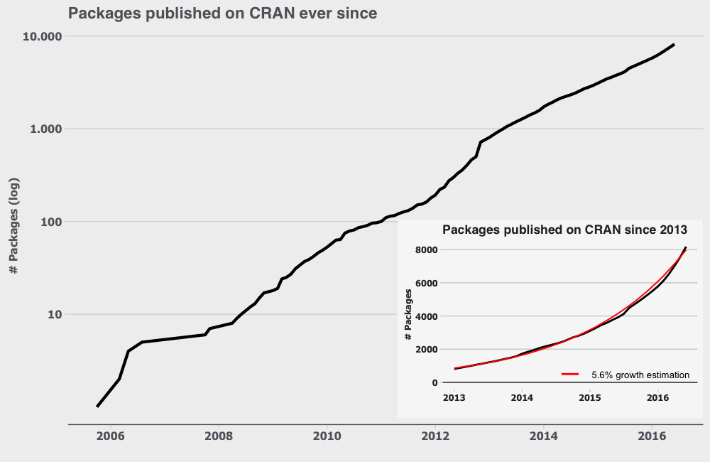

## Dlaczego Pakiet R?

- otrzymujemy **powtarzalne wyniki**,
- możemy publikować kod w R, opisując jak uzyskaliśmy te wyniki,
- przez co coraz więcej zaawansowanych metod statystycznych jest dostępnych dla zwykłego użytkownika,
- możliwość łatwej komunikacji z innymi programami,
- **darmowy**,
- **tworzy grafiki o wysokiej jakości**,
- raporty **rmarkdown** http://rmarkdown.rstudio.com/gallery.html,
- prezentacje ,
- książki https://bookdown.org/yihui/bookdown/ http://r4ds.had.co.nz
- aplikcje **shiny** https://shiny.rstudio.com/gallery/

## Dlaczego Pakiet R? przykład?

```r
simpleNetwork(networkData, fontSize = 12, linkDistance = 50, zoom = T, linkColour = "#ff3300", nodeColour = "#3182bd")
```

[interactive chart not shown]

## Literatura

- Komsta Ł. (2004) Wprowadzenie do środowiska R http://cran.r-project.org/doc/contrib/Komsta-Wprowadzenie.pdf
- Biecek P. (2014) Przewodnik po pakiecie R http://www.biecek.pl/R/PrzewodnikPoPakiecieRWydanieIIIinternet.pdf http://biecek.pl/R/
- Biecek P. (2013) Analiza danych z programem R. Modele liniowe z efektami stałymi, losowymi i mieszanymi, PWN http://biecek.pl/Analiza.Danych/ http://biecek.pl/R/
- Walesiak M. i Gatnar E. (2013) Statystyczna analiza danych z wykorzystaniem programu R, PWN http://ksiegarnia.pwn.pl/Statystyczna-analiza-danych-z-wykorzystaniem-programu-R,68603890,p.html
- Crawley MJ (2012) The R book, Wiley http://eu.wiley.com/WileyCDA/WileyTitle/productCd-0470973927.html

## Instalacja

- r-project http://www.r-project.org/
- r studio https://www.rstudio.com/
- edytory kodu, np. Tinn-R http://sourceforge.net/projects/tinn-r/
- edytory tekstu, np. Sublime Text https://www.sublimetext.com lub TextPad http://www.textpad.com

## System pomocy

```r
?mean
```

```
## starting httpd help server ... done
```

```r
example(mean)
```

```
##
## mean> x <- c(0:10, 50)
##
## mean> xm <- mean(x)
##
## mean> c(xm, mean(x, trim = 0.10))
## [1] 8.75 5.50
```

```r
help.search("mean")
```

## R - język skryptowy

- własne funkcje,
- całe analizy,
- **praca w tle (linux),**
- kod innych języków programowania w R

## PAKIETY, WTYCZKI, CAŁE BIBLIOTEKI

- pakiety
- http://www.bioconductor.org/
- http://r-forge.r-project.org/
- https://github.com

## Kilka uwag wstępu

- **kropka jako oddzielnie części całkowitej od ułamkowej,**
- argumenty funkcji oddzielamy przecinkami
- funkcje można łączyć
- tab
- strzałka do góry
- ctlr l
- ESC

## Warto skorzystać z…

- https://www.r-bloggers.com
- https://www.rstudio.com/online-learning/
- https://www.coursera.org/courses?query=R
- https://www.datacamp.com/courses/q:R
- https://www.udemy.com/courses/search/?q=R&src=ukw&lang=en
- https://opendatascience.com/blog/notable-r-package-updates/
- https://github.com/kzukowski/izoo-rtroduction

## Co jeszcze?

- 22.02.2019 Wprowadzenie do środowiska R (opis podstawowych funkcji, wczytywanie i zapisywanie danych). Analiza danych statystycznych.
- 8.03.2019 Grafika w R. Korelacja i regresja, modele liniowe.
- 22.03.2019 Testowanie….
- 5.04.2019 Pakiety, wtyczki, rozszerzenia… Zaliczenie przedmiotu

## Część praktyczna

```r
2*6
sqrt(5)
3*( pi/2)-1

x <- 2+6
myCoolVariable <- sqrt(5)
another_one_number23 <- 3*( pi/2)-1

myCoolVariable
another_one_number23

log(2)
log(2, base=2)
log(2, base=10)

dat <- c(8,5,7,9,5)
dat
dat[3]
dat-3
dat/2
dat^1.5
log(dat)
log10(dat)
```

## Część praktyczna

```r
y <- c(8,9,6,4)
srednia.arytmetyczna <- function(a){sum(a)/length(a)}
srednia.arytmetyczna(y)
mean(y)

(v1 <- c(2,8,5,4,3))
(v2 <- v1[1:4])

mediana <- function(a){
pozostalosc <- length(a)%%2
if(pozostalosc==0)(sort(a)[length(a)/2]+sort(a)[length(a)/2+1])/2
else sort(a)[ceiling(length(a)/2)]
}

mediana(v1)
mediana(v2)
```

## Część praktyczna

```r
runif(1,0,99)
a <- round(runif(10000,1,100))
mean(a)
var(a)
sd(a)
#hist(a,xlab='liczby losowe równomierne', main="")
shapiro.test(sample(a, 5000))

shapiro.test(rnorm(100, mean = 5, sd = 3))
shapiro.test(runif(100, min = 2, max = 4))
```

## Część praktyczna

```r
srednie10 <- numeric(1000)

for(i in 1:1000){
srednie10[i] <- mean(sample(a,10,T))
}

mean(srednie10)
var(srednie10)
sd(srednie10)

xx <- seq(0,100,1)
yy <- dnorm(xx,mean=50.02,sd=9.41)*5000
#hist(srednie10, xlab='srednie z 10 liczb losowych', main="")
#matlines(xx,yy,type='l', col="red")
shapiro.test(sample(srednie10, 500))
```

## Część praktyczna

```r
Pop <- c ("A", "A", "A", "A", "A", "B", "B", "B", "B")
Ht <- rnorm(9, 172, 10)
Sx <- c("Female" ,"Female" ,"Female" ,"Male" ,"Male" ,"Female" ,"Male" ,"Male" ,"Female")

myData <- data.frame(Population=Pop, Height=Ht, Sex=Sx)

dim(myData)
summary(myData)
str(myData)

myData$HeightM <- round(myData$Height/100, 0)

summary(myData)
#boxplot(myData$Height~myData$Sex)
```

## Dziękuję za uwagę

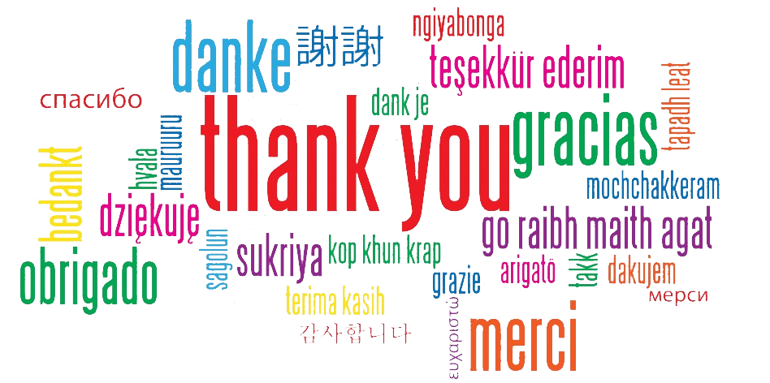